# Kernel Mean Matching

An `R` implementation of Kernel Mean Matching from http://www.cs.cmu.edu/~arthurg/papers/covariateShiftChapter.pdf. Adapted from [https://github.com/vodp/py-kmm/blob/master/Kernel%20Meam%20Matching.ipynb].

The `doKMM` function is defined in `functions.R`.

The goal of this implementation is to re-weight (in two-steps) survey data to match data from a voterfile. The steps are:

1. Weight the matched survey data so that covariate distributions match those of the file data. Covariates used are those that appear in the file.
2. Weight the unmatched survey data so that covariate distributions match those of the **weighted** matched survey data.

Another option:

1. Weight the matched survey data to the file with all file covariates
2. Weight the unmatched AND weighted matched survey data to file using just overlapping covariates

**Downside**: don’t get to use the survey-only covariates

```r
library(data.table)
library(kernlab)
library(quadprog)
setwd('~/github/bdr/')
source('functions.R')
pew_data = fread('data/pew_data.csv')
pew_data[y_dem == 1, support := '1-Dem']
pew_data[y_rep == 1, support := '2-Rep']
pew_data[y_oth == 1, support := '3-Other']

pew_data[, age_num_imp := as.numeric(age_num)]
pew_data[is.na(age_num_imp), age_num_imp := mean(pew_data$age_num, na.rm = T)]
summary(pew_data[, age_num_imp])
```

```
##    Min. 1st Qu.  Median    Mean 3rd Qu.    Max.
##   18.00   37.00   53.00   51.98   66.00   95.00
```

```r
pew_data[, age_scaled := scale(age_num_imp)/5]


#categorize variables
survey_vars = c('demo_mode', 'demo_education', 'demo_phonetype', 'demo_ideology')
file_and_survey_vars = c('demo_sex', 'demo_age_bucket', 'demo_income', 'demo_region', 'demo_race', 'demo_hispanic')
all_vars = names(pew_data)[grepl('demo|^age_scaled', names(pew_data))]
all_vars = all_vars[-which(grepl('demo_state|month_called', all_vars))]
file_only_vars = all_vars[!all_vars %in% c(survey_vars, file_and_survey_vars)]

# set n_bags
n_bags = 30

## get test train sets
testtrain = getTestTrain(data = pew_data
                         , n_holdout = 1000, n_surveyed = 2000, n_matched = 1000
                         , p_surveyed = pew_data$p_surveyed
                         , p_matched = pew_data$p_matched
)
pew_data[, .(.N, mean(y_dem)), .(holdout, surveyed, matched, voterfile)]
```

| holdout | surveyed | matched | voterfile | N | V2 |
| --- | --- | --- | --- | --- | --- |
| 0 | 0 | 0 | 1 | 2259 | 0.4785303 |
| 1 | 0 | 0 | 0 | 1000 | 0.4720000 |
| 0 | 1 | 0 | 0 | 1000 | 0.5390000 |
| 0 | 1 | 1 | 1 | 1000 | 0.4660000 |

First we’ll make the distributions of the matched survey data match the full file

```r
# set bounds for weights
B = 5.0  # upper bound; B = 1 is the unweighted solution

vars = c(file_and_survey_vars, file_only_vars)

fmla_overlap_vars = as.formula(paste0('~-1+', paste(vars, collapse = '+')))
X = model.matrix(object = fmla_overlap_vars, data = pew_data)  #not all levels

X_matched = X[which(pew_data$matched == 1),]    # data to weight
X_file = X[which(pew_data$voterfile == 1),]  # target

d_matched = as.matrix(dist(X_matched))
median(d_matched)
```

```
## [1] 3.170787
```

```r
w_matched = doKMM(X_trn = X_matched, X_tst = X_file, B = 3)
```

[output not shown]

[output not shown]

```r
# calculate weights
w_matched$weights = (nrow(X_matched)/sum(w_matched$solution)) * w_matched$solution

summary(w_matched$weights)
```

```
##       Min.    1st Qu.     Median       Mean    3rd Qu.       Max.
## -0.0000017  0.0000000  0.0000000  1.0000000  3.1292992  3.1292995
```

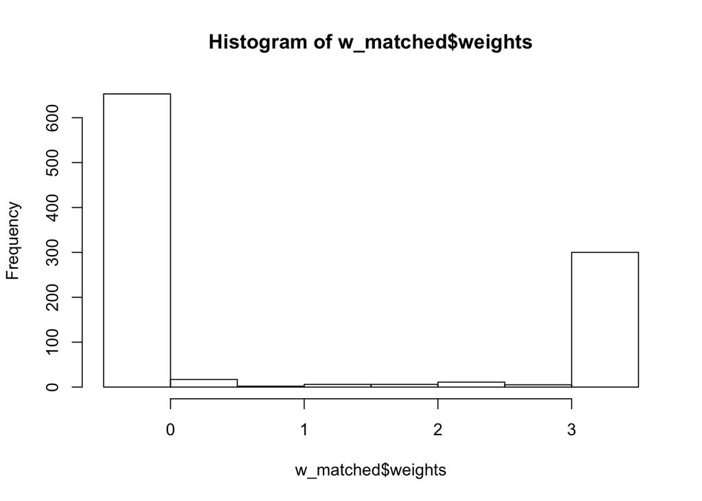

```r
hist(w_matched$weights)
```

Compare raw and weighted distributions to those of the target

```r
xtabs1 = data.table(var = colnames(X_file)
           , target = colSums(X_file)/nrow(X_file)
           , matched_raw = colSums(X_matched)/nrow(X_matched)
           , matched_weighted = t(w_matched$weights %*% X_matched/nrow(X_matched))[,1]
)
xtabs1[, diff := round(matched_weighted - target, 2)]
xtabs1
```

| var | target | matched_raw | matched_weighted | diff |
| --- | --- | --- | --- | --- |
| demo_sex01-female | 0.43111384 | 0.4540000 | 0.428046955 | 0.00 |
| demo_sex02-male | 0.56888616 | 0.5460000 | 0.571953045 | 0.00 |
| demo_age_bucket02-30to39 | 0.15710341 | 0.0460000 | 0.143947765 | -0.01 |
| demo_age_bucket03-40to49 | 0.13807917 | 0.1020000 | 0.176596016 | 0.04 |
| demo_age_bucket04-50to59 | 0.17674133 | 0.2150000 | 0.214000497 | 0.04 |
| demo_age_bucket05-60to69 | 0.16845658 | 0.2750000 | 0.201077947 | 0.03 |
| demo_age_bucket06-Over 70 | 0.16109236 | 0.3380000 | 0.189274594 | 0.03 |
| demo_age_bucket99-DNK/refused | 0.02270635 | 0.0100000 | 0.031292992 | 0.01 |
| demo_income02-10to20k | 0.07272169 | 0.0510000 | 0.072613182 | 0.00 |
| demo_income03-20to30k | 0.08714330 | 0.0810000 | 0.088507191 | 0.00 |

[output cut: 42 more lines]

```r
B = 5.0  # upper bound; B = 1 is the unweighted solution

vars = c(survey_vars,file_and_survey_vars)

fmla_survey_vars = as.formula(paste0('~-1+', paste(vars, collapse = '+')))
X = model.matrix(object = fmla_survey_vars, data = pew_data)

X_matched = X[which(pew_data$matched == 1),]    # target
X_matched_weighted = diag(w_matched$weights) %*% X_matched

X_unmatched = X[which(pew_data$matched == 0 & pew_data$surveyed == 1),]  # data to weight

d_v2 = dist(rbind(X_matched, X_unmatched))
median(d_v2^2)
```

```
## [1] 10
```

```r
w_unmatched = doKMM(X_trn = X_unmatched, X_tst = X_matched_weighted, B = 5)

w_unmatched$weights = w_unmatched$solution * (nrow(X_unmatched)/sum(w_unmatched$solution))

X_unmatched_weighted = diag(w_unmatched$weights) %*% X_unmatched

summary(w_unmatched$weights)
```

```
##    Min. 1st Qu.  Median    Mean 3rd Qu.    Max.
## 0.00000 0.00000 0.08891 1.00000 1.74604 4.99990
```

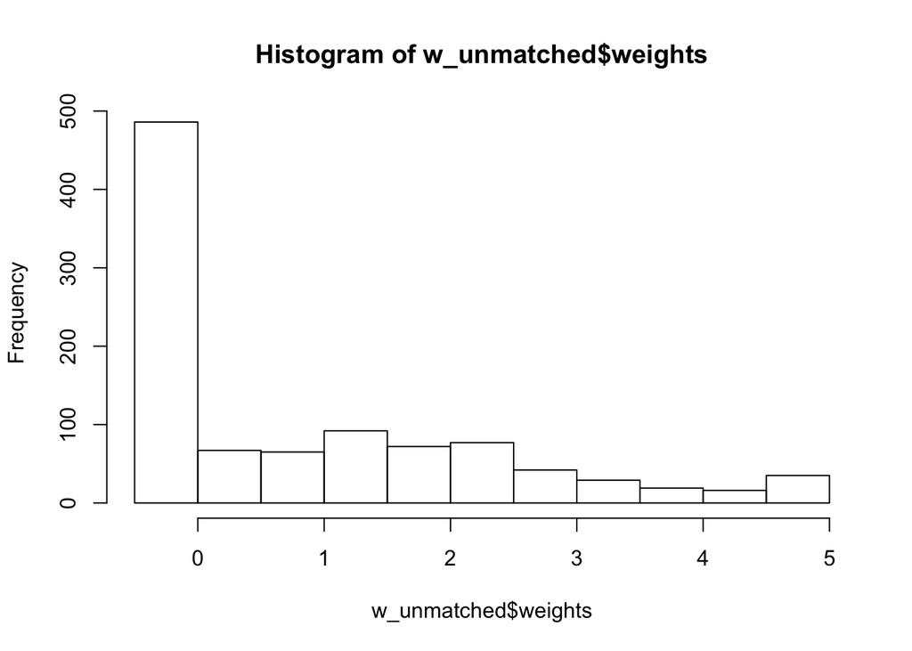

```r
hist(w_unmatched$weights)
```

Compare raw and weighted distributions to those of the target

** setting sigma is key. Controls balance between variance of weights and how well weighted margins match target margins. Should set this with CV or soomething.

```r
xtabs2 = data.table(var = colnames(X_matched)
           #, target_raw = colSums(X_matched)/nrow(X_matched)
           , target_weighted = colSums(X_matched_weighted)/nrow(X_matched_weighted)
           , unmatched_raw = colSums(X_unmatched)/nrow(X_unmatched)
           , unmatched_weighted = t((w_unmatched$weights %*% X_unmatched)/nrow(X_matched))[,1]
)

xtabs2[, diff := round(unmatched_weighted - target_weighted, 2)]
xtabs2
```

| var | target_weighted | unmatched_raw | unmatched_weighted | diff |
| --- | --- | --- | --- | --- |
| demo_modecell | 0.87721477 | 0.712 | 0.87720868 | 0 |
| demo_modelandline | 0.12278523 | 0.288 | 0.12279132 | 0 |
| demo_education02-bach | 0.33748635 | 0.310 | 0.33747988 | 0 |
| demo_education03-assoc | 0.20104238 | 0.218 | 0.20103814 | 0 |
| demo_education04-HS | 0.15410727 | 0.166 | 0.15410378 | 0 |
| demo_education05-less than HS | 0.05795662 | 0.061 | 0.05795465 | 0 |
| demo_education99-DK/refused | 0.01251720 | 0.006 | 0.01251535 | 0 |
| demo_phonetype02-LL only | 0.01251720 | 0.044 | 0.01251637 | 0 |
| demo_phonetype03-Cell only | 0.57101450 | 0.431 | 0.57100430 | 0 |
| demo_ideology02-Liberal | 0.19574853 | 0.181 | 0.19574434 | 0 |

[output cut: 27 more lines]

Are we actually making the kernel means closer?

```r
  #rbf1 = rbfdot(sigma = 9)
lin = vanilladot()
  K1 = kernelMatrix(lin, x = X_matched, X_matched)
  K2 = kernelMatrix(lin, x = X_matched_weighted, X_matched_weighted)
  K3 = kernelMatrix(lin, x = X_matched_weighted, X_unmatched)
  K4 = kernelMatrix(lin, x = X_matched_weighted, X_unmatched_weighted)

  dist(rbind(
    rowSums(K1)/nrow(K1)
     ,rowSums(K2)/ncol(K2)
  ,rowSums(K3)/ncol(K3)
  ,rowSums(K4)/ncol(K4)
  ))
```

```
##              1            2            3
## 2 1.783407e+02
## 3 1.636297e+02 1.996985e+01
## 4 1.783378e+02 3.512645e-03 1.996665e+01
```